# BMW vs Volkswagen

Isabel Afán de Ribera

30 noviembre 2020

## Objetivo

El objetivo de este análisis sobre series temporales es obtener el modelo Garch más adecuado para los activos de BMW y posteriormente plantear un modelo VAR mensual entre los activos de BMW y Volkswagen.

## Modelo Garch BMW

### Fluctuación en los precios, rentabilidad y volatilidad de BMW

Se ha extraído de Yahoo Finance los datos sobre las acciones de la compañía automovilística alemana BMW desde enero de 2014 hasta la fecha actual con el fin de analizar la evolución de su precio, rendimiento y volatilidad.

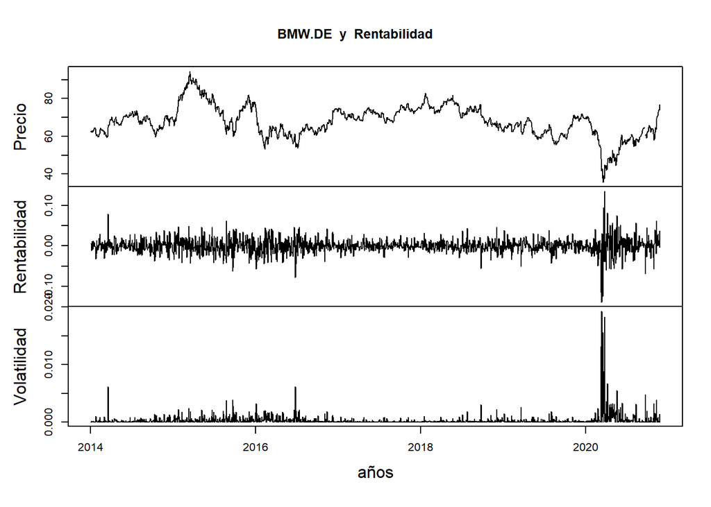

En estos gráficos puede visualizarse la variabilidad que se produce a lo largo del tiempo en el precio, rendimiento y volatilidad de los activos de BMW. Como en cualquier otro activo la varianza y la desviación tipica fluctuan. Además, es destacable en el año 2020 el pico de caída en el precio que se ve reflejado en un pico de subida en la volatilidad.

### Análisis de residuos

T-test

```
##
##  One Sample t-test
##
## data:  dRentCont
## t = 0.27691, df = 1745, p-value = 0.7819
## alternative hypothesis: true mean is not equal to 0
## 95 percent confidence interval:
##  -0.0007138974  0.0009486177
## sample estimates:
##    mean of x
## 0.0001173601
```

A través del t-test se comprueba si los valores tienen residuos con media 0. Se ha obtenido un p-value de 0.7819 y por tanto puede decirse con un 95% de confianza que los residuos poseen una media estadisticamente igual a 0 con un intervalo de confianza de (-0.0007138974, 0.0009486177).

Representación gráfica de residuos

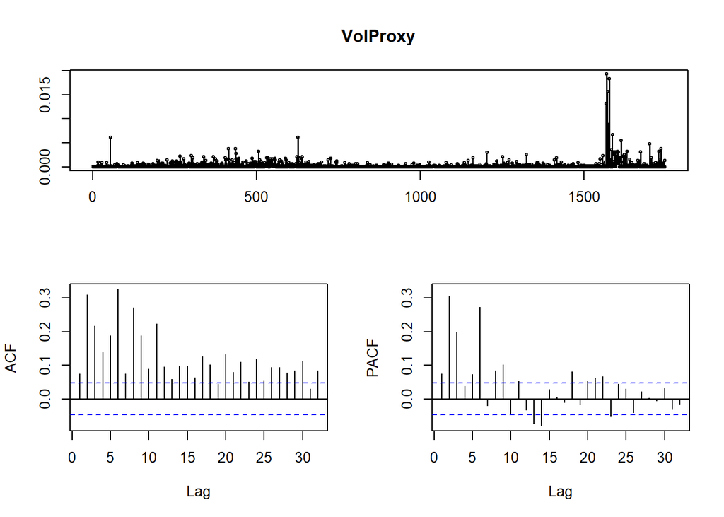

Estas gráficas reflejan una serie temporal no estacionaria, es decir, con media y varianza cambiante. Si nos fijamos en la autocorrelación simple (acf) y la autocorrelación parcial (pacf) vemos que los retardos se salen de las bandas discontinuas azules, lo cual nos indica que el coeficiente de autocorrelación no es cero y, por tanto, los errores de los residuos no son ruido blanco.

Ljung-Box Test

```
##
##  Box-Ljung test
##
## data:  VolProxy
## X-squared = 759.49, df = 10, p-value < 2.2e-16
```

```
##
##  Box-Ljung test
##
## data:  VolProxy
## X-squared = 992.14, df = 20, p-value < 2.2e-16
```

```
##
##  Box-Ljung test
##
## data:  VolProxy
## X-squared = 1228.9, df = 40, p-value < 2.2e-16
```

Para confirmar realizamos el test Box-Ljung y obtenemos para todos los retardos un p-value inferior a 0.05 con lo cual rechazamos la Ho, existe autocorrelación y no hay ruido blanco.

LM test

```
##
## Call:
## lm(formula = atsq ~ x)
##
## Residuals:
##        Min         1Q     Median         3Q        Max
## -0.0047719 -0.0002216 -0.0001073  0.0000522  0.0181218
##
## Coefficients:
##               Estimate Std. Error t value Pr(>|t|)
## (Intercept)  0.0000898  0.0000256   3.507 0.000464 ***
## x1          -0.0367091  0.0241898  -1.518 0.129315
## x2           0.2365680  0.0242030   9.774  < 2e-16 ***
## x3           0.0928796  0.0248211   3.742 0.000189 ***
## x4          -0.0115348  0.0249254  -0.463 0.643587
## x5           0.0845979  0.0249186   3.395 0.000702 ***
## x6           0.2479274  0.0250053   9.915  < 2e-16 ***
## x7          -0.0227848  0.0256288  -0.889 0.374111
## x8           0.1235828  0.0255516   4.837 1.44e-06 ***
## x9           0.0750661  0.0257088   2.920 0.003548 **
## x10         -0.0412466  0.0257119  -1.604 0.108859
## x11          0.0788966  0.0257162   3.068 0.002189 **
## x12         -0.0448780  0.0258371  -1.737 0.082575 .
## x13         -0.0846044  0.0257036  -3.292 0.001017 **
## x14         -0.0894033  0.0257829  -3.468 0.000538 ***
## x15          0.0183294  0.0251310   0.729 0.465887
## x16         -0.0121155  0.0250696  -0.483 0.628962
## x17         -0.0074174  0.0250702  -0.296 0.767370
## x18          0.0678835  0.0249983   2.716 0.006684 **
## x19         -0.0141094  0.0243582  -0.579 0.562500
## x20          0.0549062  0.0244001   2.250 0.024560 *
## ---
## Signif. codes:  0 '***' 0.001 '**' 0.01 '*' 0.05 '.' 0.1 ' ' 1
##
## Residual standard error: 0.0008744 on 1705 degrees of freedom
## Multiple R-squared:  0.2416, Adjusted R-squared:  0.2327
## F-statistic: 27.15 on 20 and 1705 DF,  p-value: < 2.2e-16
```

Por último, con el Lagrange Multiplier Test (LM) se ha comprobado que el modelo tiene Garch, p-value < 2.2e-16.

### Modelo Garch

Modelo autorregresivo de heterocedasticidad condicional que busca la modelización de la volatilidad (desviación típica) en la cual esta dependerá de observaciones pasadas. En series financieras la variabilidad no es fija sino todo lo contrario, es muy cambiante.

Modelo ARCH

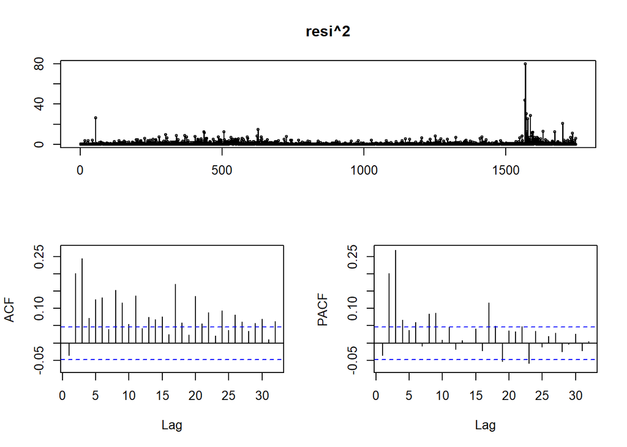

En los resultados obtenidos con un modelo ARCH con varianza igual a 1 (q=1), es decir, con heterocedasticidad condicional autorregresiva de orden 1. Volvemos a ver que los residuos (esta vez al cuadrado) no son ruido blanco y existe autocorrelación.

Modelo GARCH

```
##
## Title:
##  GARCH Modelling
##
## Call:
##  garchFit(formula = ~1 + garch(1, 1), data = dRentCont, trace = F)
##
## Mean and Variance Equation:
##  data ~ 1 + garch(1, 1)
## <environment: 0x000000001f6f2388>
##  [data = dRentCont]
##
## Conditional Distribution:
##  norm
##
## Coefficient(s):
##         mu       omega      alpha1       beta1
## 3.1580e-04  2.4828e-06  4.9989e-02  9.4277e-01
##
## Std. Errors:
##  based on Hessian
##
## Error Analysis:
##         Estimate  Std. Error  t value Pr(>|t|)
## mu     3.158e-04   3.362e-04    0.939   0.3475
## omega  2.483e-06   9.747e-07    2.547   0.0109 *
## alpha1 4.999e-02   8.009e-03    6.242 4.32e-10 ***
## beta1  9.428e-01   9.525e-03   98.980  < 2e-16 ***
## ---
## Signif. codes:  0 '***' 0.001 '**' 0.01 '*' 0.05 '.' 0.1 ' ' 1
##
## Log Likelihood:
##  4791.573    normalized:  2.744314
##
## Description:
##  Mon Nov 30 10:09:15 2020 by user: iafan
##
##
## Standardised Residuals Tests:
##                                 Statistic p-Value
##  Jarque-Bera Test   R    Chi^2  748.1161  0
##  Shapiro-Wilk Test  R    W      0.9722322 0
##  Ljung-Box Test     R    Q(10)  22.00303  0.01508915
##  Ljung-Box Test     R    Q(15)  26.19759  0.03599638
##  Ljung-Box Test     R    Q(20)  32.23366  0.04087131
##  Ljung-Box Test     R^2  Q(10)  21.24155  0.01947082
##  Ljung-Box Test     R^2  Q(15)  22.70466  0.09061503
##  Ljung-Box Test     R^2  Q(20)  26.09695  0.1626338
##  LM Arch Test       R    TR^2   21.76517  0.04023749
##
## Information Criterion Statistics:
##       AIC       BIC       SIC      HQIC
## -5.484046 -5.471526 -5.484057 -5.479418
```

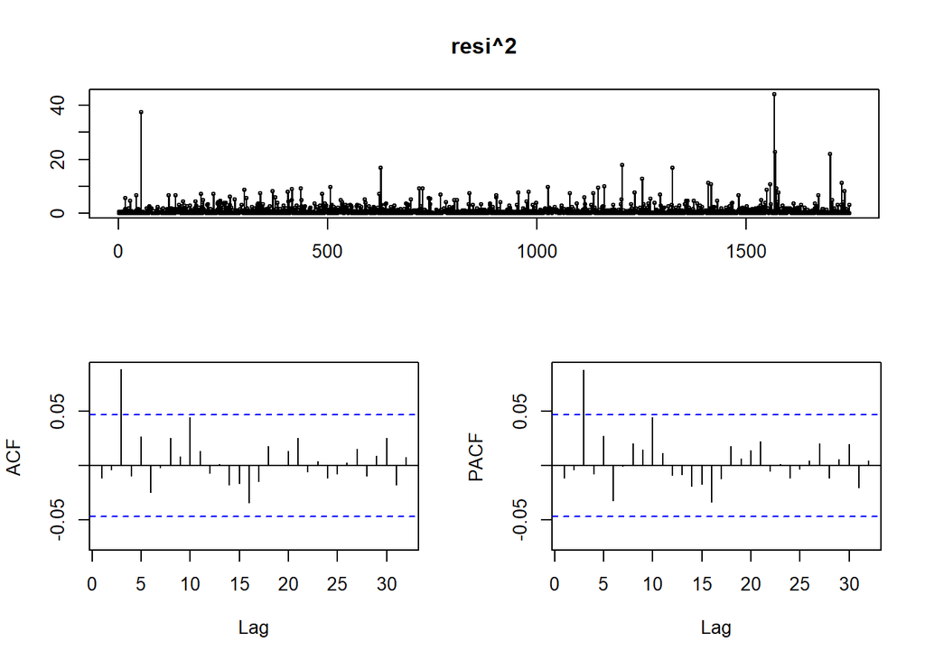

Representación gráfica de la volatilidad

En el siguiente grafico se puede observar los cambios en la volatilidad de las acciones de BMW desde 2014 hasta 2020, donde resulta destacable el pico de incremento de la volatilidad en marzo de 2020 debido al COVID-19 que generó mucha inestabilidad en los mercados financieros siendo uno de los sectores más afectados en de la industria del automóvil.

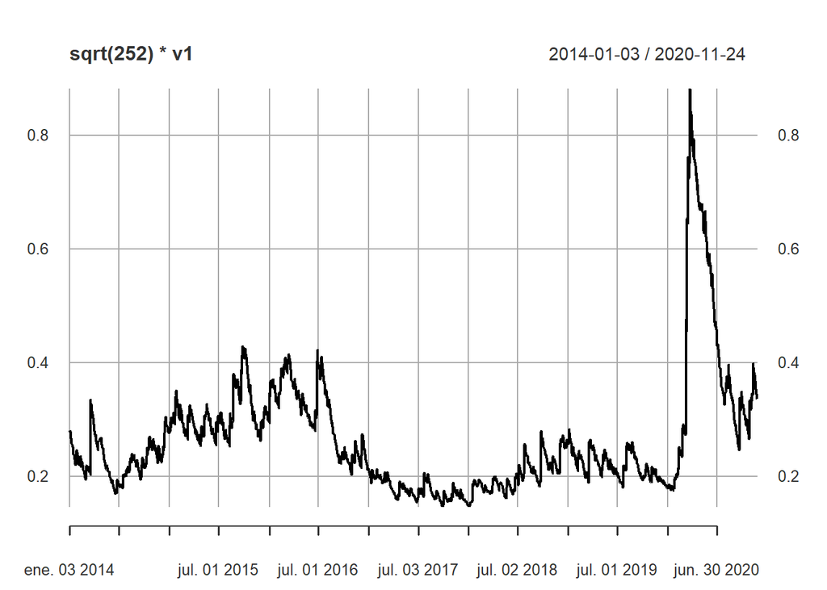

Análisis de residuos

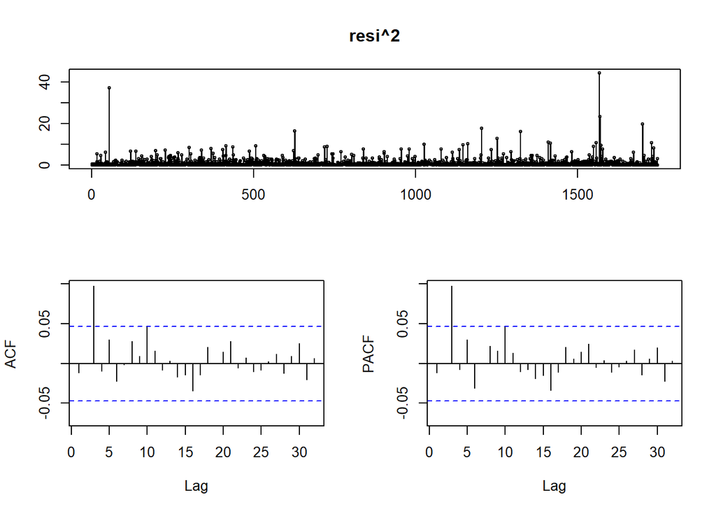

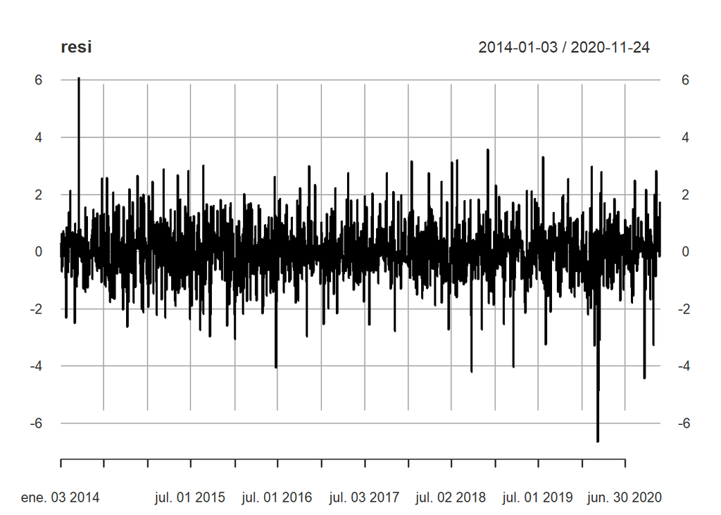

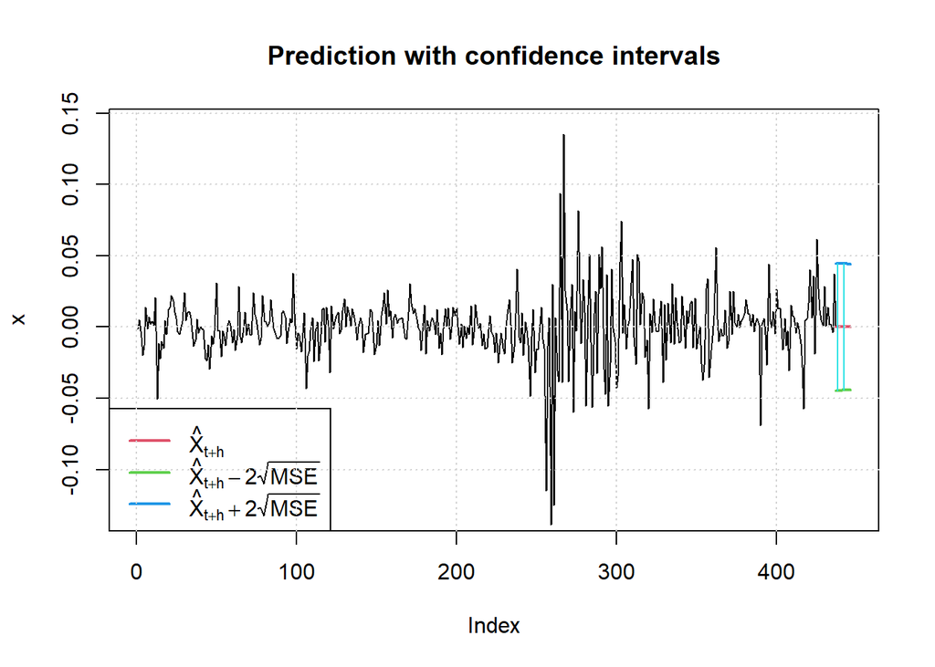

```
##    meanForecast  meanError standardDeviation lowerInterval upperInterval
## 1  1.915174e-05 0.02221970        0.02221970   -0.04442024    0.04445855
## 2  1.915174e-05 0.02221341        0.02221341   -0.04440767    0.04444597
## 3  1.915174e-05 0.02220715        0.02220715   -0.04439515    0.04443345
## 4  1.915174e-05 0.02220092        0.02220092   -0.04438268    0.04442098
## 5  1.915174e-05 0.02219471        0.02219471   -0.04437027    0.04440857
## 6  1.915174e-05 0.02218853        0.02218853   -0.04435792    0.04439622
## 7  1.915174e-05 0.02218238        0.02218238   -0.04434561    0.04438392
## 8  1.915174e-05 0.02217626        0.02217626   -0.04433337    0.04437167
## 9  1.915174e-05 0.02217016        0.02217016   -0.04432117    0.04435948
## 10 1.915174e-05 0.02216409        0.02216409   -0.04430904    0.04434734
```

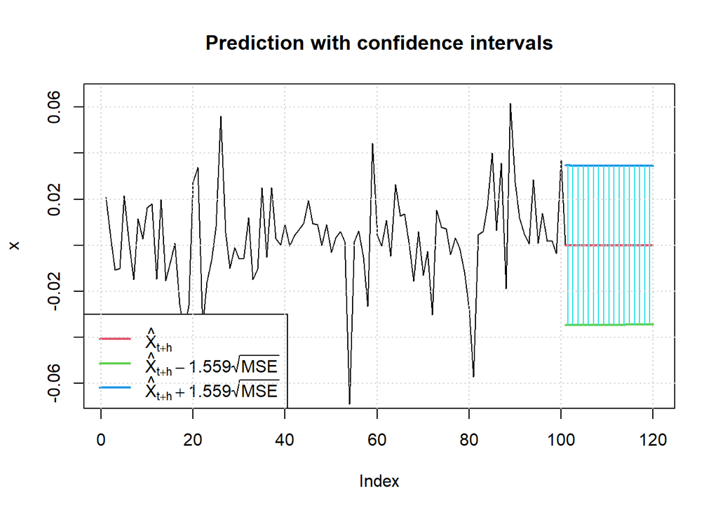

```
##    meanForecast  meanError standardDeviation lowerInterval upperInterval
## 1  1.915174e-05 0.02221970        0.02221970   -0.03463016    0.03466847
## 2  1.915174e-05 0.02221341        0.02221341   -0.03462036    0.03465866
## 3  1.915174e-05 0.02220715        0.02220715   -0.03461060    0.03464890
## 4  1.915174e-05 0.02220092        0.02220092   -0.03460088    0.03463918
## 5  1.915174e-05 0.02219471        0.02219471   -0.03459120    0.03462950
## 6  1.915174e-05 0.02218853        0.02218853   -0.03458157    0.03461987
## 7  1.915174e-05 0.02218238        0.02218238   -0.03457198    0.03461028
## 8  1.915174e-05 0.02217626        0.02217626   -0.03456243    0.03460073
## 9  1.915174e-05 0.02217016        0.02217016   -0.03455292    0.03459122
## 10 1.915174e-05 0.02216409        0.02216409   -0.03454345    0.03458176
## 11 1.915174e-05 0.02215805        0.02215805   -0.03453403    0.03457234
## 12 1.915174e-05 0.02215203        0.02215203   -0.03452465    0.03456295
## 13 1.915174e-05 0.02214605        0.02214605   -0.03451531    0.03455361
## 14 1.915174e-05 0.02214008        0.02214008   -0.03450601    0.03454432
## 15 1.915174e-05 0.02213415        0.02213415   -0.03449675    0.03453506
## 16 1.915174e-05 0.02212824        0.02212824   -0.03448754    0.03452584
## 17 1.915174e-05 0.02212235        0.02212235   -0.03447836    0.03451666
## 18 1.915174e-05 0.02211649        0.02211649   -0.03446923    0.03450753
## 19 1.915174e-05 0.02211066        0.02211066   -0.03446013    0.03449843
## 20 1.915174e-05 0.02210485        0.02210485   -0.03445108    0.03448938
```

## Modelo VAR mensual entre los activos de BMW y Volkswagen

Nuestro objetivo aquí es saber si cambios en una de las variables afectan a la otra. Para conocer si existe relación bidireccional se emplean los vectores autorregresivos VAR.

### Identificacion del número de retardos a incluir en el VAR

```
## $selection
## AIC(n)  HQ(n)  SC(n) FPE(n)
##      1      1      1      1
##
## $criteria
##                    1             2             3             4             5
## AIC(n) -1.021562e+01 -1.020813e+01 -1.012514e+01 -1.003793e+01 -9.956727e+00
## HQ(n)  -1.014060e+01 -1.008309e+01 -9.950085e+00 -9.812862e+00 -9.681640e+00
## SC(n)  -1.002737e+01 -9.894367e+00 -9.685874e+00 -9.473162e+00 -9.266451e+00
## FPE(n)  3.659753e-05  3.688525e-05  4.010707e-05  4.382041e-05  4.762744e-05
##                    6             7             8             9            10
## AIC(n) -9.975043e+00 -9.9682666102 -9.924234e+00 -9.847507e+00 -9.888802e+00
## HQ(n)  -9.649940e+00 -9.5931483995 -9.499100e+00 -9.372358e+00 -9.363637e+00
## SC(n)  -9.159263e+00 -9.0269819084 -8.857445e+00 -8.655213e+00 -8.571004e+00
## FPE(n)  4.690595e-05  0.0000474233  4.983341e-05  5.419108e-05  5.246391e-05
```

Para cada longitud de rezago, la tabla reporta (de arriba hacia abajo), el Criterio de información de Akaike (AIC), Criterio de informacion de Hannan y Quinn (HQ), el criterio información bayesiana de Schwarz (SC) y el error de predicción final de Akaike (FPE). Los cuatro criterios de información han elegido en este caso 1 rezago.

### Estimación del Modelo VAR

### Relaciones temporales: Prueba de Causalidad Granger

```r
#causalidad de granger, queremos saber si hay efecto bidideccional
causality(model.var1)
```

```
## $Granger
##
##  Granger causality H0: BMW do not Granger-cause VOW
##
## data:  VAR object model.var1
## F-Test = 6.0216, df1 = 1, df2 = 160, p-value = 0.0152
##
##
## $Instant
##
##  H0: No instantaneous causality between: BMW and VOW
##
## data:  VAR object model.var1
## Chi-squared = 28.842, df = 1, p-value = 7.852e-08
```

```r
# p value 0.0152 rechazamos la Ho
# p value 7.852e-08 rechazamos la Ho
```

Los p-value obtenidos son menores del 5%, por lo tanto, en ambos casos se rechaza la Ho. Por un lado, si hay causalidad de Granger, es decir, un shock en BMW causa Granger un shock en Volkswagen, al menos en nuestro periodo de estimación. Y, por otro, si hay relación instantánea entre BMW y Volkswagen

### Función de Impulso - Respuesta

Las funciones de impulso respuesta muestran los efectos de los shock en la trayectoria de ajuste de las variables.

```
##
## Impulse response coefficients
## $BMW
##                 BMW           VOW
##  [1,]  7.924169e-02  7.325929e-02
##  [2,] -3.947396e-03  1.474779e-02
##  [3,] -6.333276e-03 -7.329468e-03
##  [4,]  8.387888e-04 -6.501958e-04
##  [5,]  4.642413e-04  6.671627e-04
##  [6,] -1.075912e-04  1.096014e-06
##  [7,] -3.033488e-05 -5.607320e-05
##  [8,]  1.145958e-05  4.401662e-06
##  [9,]  1.627214e-06  4.352674e-06
## [10,] -1.092041e-06 -7.181859e-07
## [11,] -4.903393e-08 -3.077028e-07
```

[output cut: 74 more lines]

Visualización del impulso-respuesta:

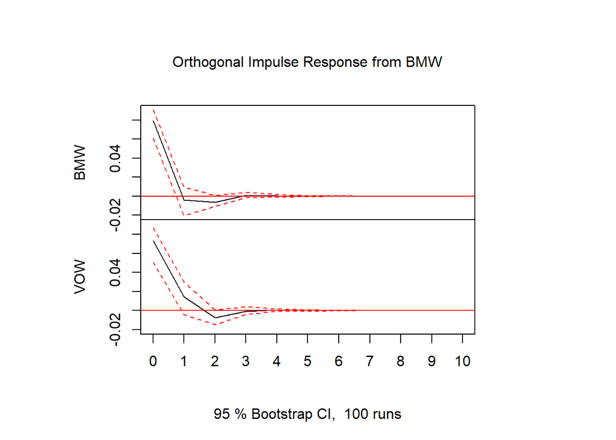

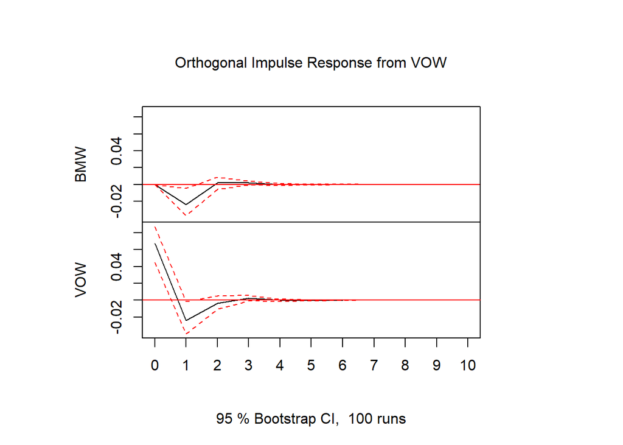

En estos gráficos puede verse el efecto que produce un shock en la serie temporal de BMW en la de Volkswagen y vicerversa. Por ejemplo, un shock en BMW supone una fuerte caída en Volkswagen que luego se estabilizaría, como puede observarse en la primera gráfica. En el caso contario, es decir, en el caso de que se produzca un shock en Volkswagen el impulso respuesta en BMW sería también una caída aunque no tan pronunciada, que luego se recuperaría hasta estabilizarse.

Predicciones sobre rendimientos esperados:

```
## $BMW
##               fcst      lower     upper        CI
## [1,] -2.294013e-03 -0.1576049 0.1530168 0.1553109
## [2,] -2.555715e-02 -0.1879488 0.1368345 0.1623917
## [3,]  2.240621e-03 -0.1606679 0.1651492 0.1629086
## [4,]  1.965083e-03 -0.1609921 0.1649223 0.1629572
## [5,] -3.455023e-04 -0.1633064 0.1626154 0.1629609
## [6,] -1.372131e-04 -0.1630984 0.1628240 0.1629612
## [7,]  3.998912e-05 -0.1629212 0.1630012 0.1629612
## [8,]  8.309643e-06 -0.1629529 0.1629695 0.1629612
##
## $VOW
##               fcst      lower     upper        CI
## [1,]  7.020504e-02 -0.1247257 0.2651357 0.1949307
## [2,] -2.635350e-02 -0.2290034 0.1762963 0.2026498
## [3,] -3.779364e-03 -0.2070680 0.1995093 0.2032886
## [4,]  2.514344e-03 -0.2008292 0.2058579 0.2033435
## [5,]  1.156513e-04 -0.2032322 0.2034635 0.2033479
## [6,] -2.202609e-04 -0.2035685 0.2031280 0.2033483
## [7,]  7.946472e-06 -0.2033403 0.2033562 0.2033483
## [8,]  1.784651e-05 -0.2033304 0.2033661 0.2033483
```

## Referencias

- An Introduction to Impulse Response Analysis of VAR Models. Disponible en: https://www.r-econometrics.com/timeseries/irf/
- Modelos VAR. Disponible en: https://rpubs.com/vchung/var_ejemplo
- Queralt, R.(2020). Series Temporales - Modelos GARCH y Modelos VAR. Colegio Universitario de Estudios Financieros